# Covid Analysis (Deaths vs Cases)

Fasih Atif

Note: HTML version differs from html version in terms of formatting.

The COVID-19 pandemic is an unprecedented global crisis having affected every corner of the globe and the lives of every individual. Some countries have fared better in being able to control the Covid spread and keep the Covid death rate low while others have suffered huge causalities.

Using the John Hopkins database on Covid-19 data, i would like to observe if there is any pattern of association between deaths per capita and confirmed cases per capita. For research purposes, i would only be using the data for the day of 09-24-2020.

We will be working with 4 main variables during the analysis:

1. country: The name of each country
2. death: Total number of deaths in each country
3. confirmed: Total number of registered cases in each country
4. population: Number of people with permanent residence residing in each country

There were a lot of data quality issues that had to be dealt with before analysis. In many places, the country names were spelled differently which had to be corrected. There were some organizations, unions, and organizations listed in the country column which had to be removed so that we could keep our focus on countries. The numeric columns had missing values so the rows with missing values had to be entirely removed.

| country | death | confirmed | cases_per_capita | deaths_per_capita | population |
| --- | --- | --- | --- | --- | --- |
| Afghanistan | 1451 | 39170 | 1029.66 | 38.14 | 38.041754 |
| Albania | 370 | 12921 | 4527.03 | 129.63 | 2.854191 |
| Algeria | 1703 | 50579 | 1174.81 | 39.56 | 43.053054 |

## **Summary statistics for X and Y variables**

|  | mean | median | std | min | max |
| --- | --- | --- | --- | --- | --- |
| cases_per_capita | 5372.69453 | 2625.77500 | 7300.6536 | 8.78000 | 43934.340 |
| deaths_per_capita | 132.94300 | 47.56000 | 211.1308 | 0.09000 | 1240.400 |
| population | 44.52144 | 10.27744 | 154.3139 | 0.03386 | 1397.715 |

## **Investigation of the transformation of our variables**

We will be working with the following equation:

*deaths_per_capita = alpha + beta * cases_per_capita*

It is important to think beforehand what kind of transformations are feasible or not. We would like a transformation that explains the association between the dependent and independent variable clearly and interpretations that make the most sense. Hence, we will visualize the model with different log transformations.

**Level-Level Model:** deaths_per_capita = alpha + beta * cases_per_capita (**Figure 2**)

**Level - Log Model:** deaths_per_capita = alpha + beta * ln_cases_per_capita (**Figure 3**)

**Log - Level Model:** ln_deaths_per_capita = alpha + beta * cases_per_capita (**Figure 4**)

**Log - Log Model:** ln_deaths_per_capita = alpha + beta * ln_cases_per_capita (**Figure 5**)

Based on model comparison, our chosen model is ln_deaths_per_capita ~ ln_cases_per_capita

- Substantive Reasoning: Level changes are hard to interpret due to non linearity of curves. A percentage change gives a better summary of the relationship between deaths_per_capita and cases_per_capita.
- Statistical Reasoning: It is a linear model which is easy to interpret and captures the variation well

## **Log Transformation of variables for Regression**

Based on our investigation, we found out that log transformations would work best on both independent and dependent variables. So, we created new log variables for deaths per capita and confirmed cases per capita.

## Estimating different Regression models

*ln_deaths_per_capita = alpha + beta * ln_cases_per_capita*

Interpretation of B1: This model and its results tells us that for a 10% increase in confirmed cases per capita per million, we observe 9.4% higher deaths per capita per million on average.

## Residual Analysis

**Countries with largest negative errors**

This category includes countries like Maldives, Sri Lanka, Qatar, Burundi, and Singapore. The largest negative deviance from the predicted value is found in `Burundi` with predicted deaths per capita of `27.66`, but the real value is only `25.1`.These countries have predicted Y values greater than the log values of deaths_per_capita. This means that their death_per_capita per million is lower than what is predicted. It needs to be investigated further as to what initiatives have led to a lower deaths per capita per million value.

**Countries with largest positive errors**

This category includes countries such as Belgium, Italy, Mexico, United Kingdom, and Yemen. - The largest positive deviance from the predicted value is found in `Belgium` with predicted deaths per capita of ‘32.65’, but the real value is `34.29`. These countries have predicted Y values lower than their actual ln_deaths_per_capita value. This means that their death_per_capita per million is higher than what is predicted. Again, further investigation would be required to see what policies and actions led to higher than predicted ln_death_per_capita values.

## Testing hypothesis

We test the following hypothesis:

H0 - B= 0 : There is no relationship between ln_deaths_per_capita and ln_cases_per_capita

HA - B != 0 : There is a relationship between between ln_deaths_per_capita and ln_cases_per_capita

```
##
## Call:
## lm_robust(formula = ln_deaths_per_capita ~ ln_cases_per_capita,
##     data = df, se_type = "HC2")
##
## Standard error type:  HC2
##
## Coefficients:
##                     Estimate Std. Error t value  Pr(>|t|) CI Lower CI Upper  DF
## (Intercept)          -3.4531    0.34222  -10.09 5.164e-19  -4.1287   -2.777 168
## ln_cases_per_capita   0.9379    0.04525   20.73 3.652e-48   0.8486    1.027 168
##
## Multiple R-squared:  0.7863 ,    Adjusted R-squared:  0.785
## F-statistic: 429.7 on 1 and 168 DF,  p-value: < 2.2e-16
```

## Appendix

**Figure 1: Histogram for confirmed cases and deaths**

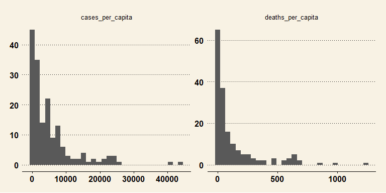

**Figure 2: Level - Level Model**

The graph shows a non-linear pattern with majority of values clustered towards the left while a few extreme values pull on the conditional mean towards the right hand side. We will run log models on the independent and dependent variables to check if we get better results.

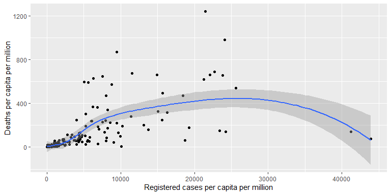

**Figure 3: Level - Log Model**

We transformed the independent variable (cases_per_capita) and visualized the model. Non-parametric regression on the model shows a non-linear pattern here as well. Non parametric regressions are very volatile at both ends of the curves as you can see by the wide shaded area (confidence intervals).

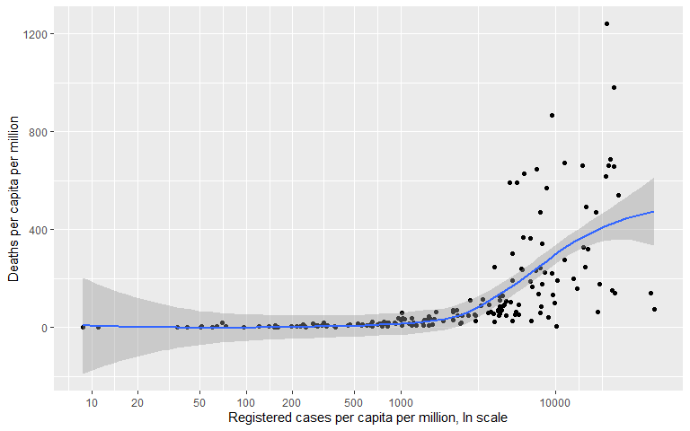

**Figure 4: Log - Level Model**

The graph shows a non linear pattern with majority of values clustered on the left side making the graph harder to interpret and analyze.

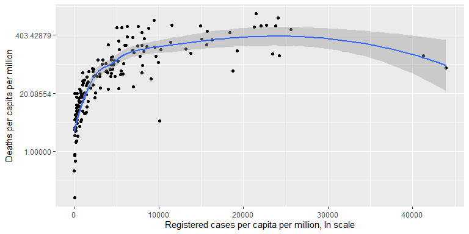

**Figure 5: Log - Log Model**

This transformation shows a linear pattern with the values distributed across the graph giving us a better approximation.

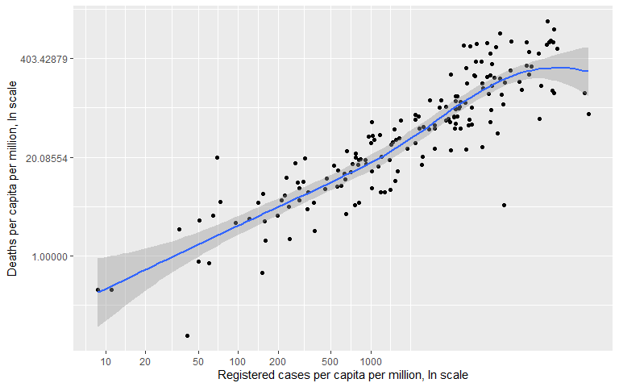

**Figure 6: Estimating model comparison**

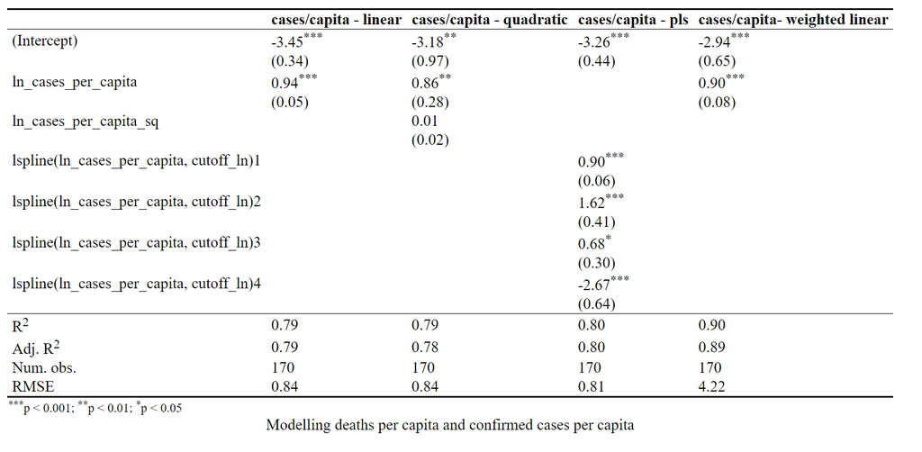

**Figure 7: Linear Regression Visualization**

*ln_deaths_per_capita = alpha + beta * ln_cases_per_capita*

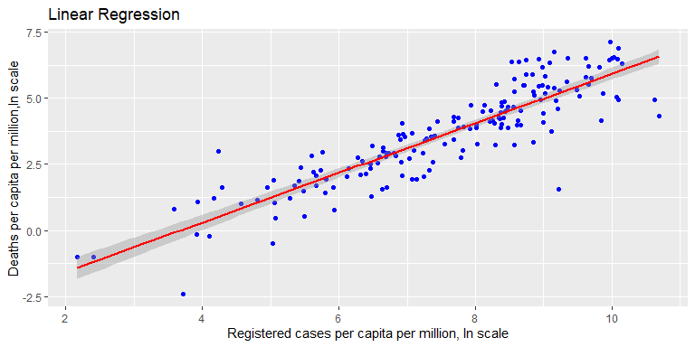

**Figure 8: Quadratic Regression Visualization**

*ln_deaths_per_capita = alpha + beta_1 * ln_cases_per_capita + beta_2 * ln_cases_per_capita^2*

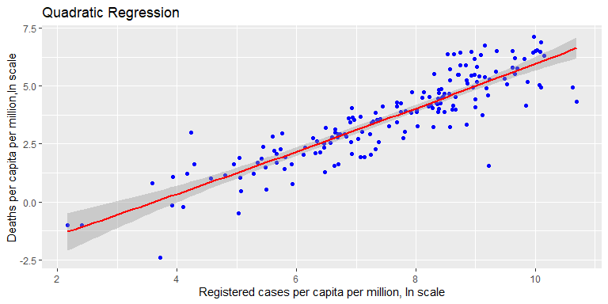

**Figure 9: Piecewise Linear Spline Regression Visualization**

[figure not shown]

**Figure 10: Weighted OLS Regression Visualization**

*ln_deaths_per_capita = alpha + beta * ln_cases_per_capita, weights: population*

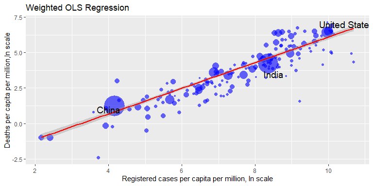